# Optimal Treatment Analysis

## Outcome Variable

**Outcome Variable:** ever_stunted

## Predictor Variables

**Intervention Variable:** mwtkg

**Adjustment Set:**

- arm
- W_mage
- meducyrs
- feducyrs
- single
- brthmon
- delta_W_mage
- delta_meducyrs
- delta_feducyrs
- delta_single
- delta_brthmon

## Stratifying Variables

The analysis was stratified on these variable(s):

- agecat
- studyid
- country

## Data Summary

| agecat | studyid | country | mwtkg | ever_stunted | n_cell | n |
| --- | --- | --- | --- | --- | --- | --- |
| 0-24 months | ki0047075b-MAL-ED | BANGLADESH | >=58 kg | 0 | 29 | 254 |
| 0-24 months | ki0047075b-MAL-ED | BANGLADESH | >=58 kg | 1 | 19 | 254 |
| 0-24 months | ki0047075b-MAL-ED | BANGLADESH | <52 kg | 0 | 49 | 254 |
| 0-24 months | ki0047075b-MAL-ED | BANGLADESH | <52 kg | 1 | 113 | 254 |
| 0-24 months | ki0047075b-MAL-ED | BANGLADESH | [52-58) kg | 0 | 21 | 254 |
| 0-24 months | ki0047075b-MAL-ED | BANGLADESH | [52-58) kg | 1 | 23 | 254 |
| 0-24 months | ki0047075b-MAL-ED | BRAZIL | >=58 kg | 0 | 110 | 221 |
| 0-24 months | ki0047075b-MAL-ED | BRAZIL | >=58 kg | 1 | 33 | 221 |
| 0-24 months | ki0047075b-MAL-ED | BRAZIL | <52 kg | 0 | 31 | 221 |
| 0-24 months | ki0047075b-MAL-ED | BRAZIL | <52 kg | 1 | 11 | 221 |
| 0-24 months | ki0047075b-MAL-ED | BRAZIL | [52-58) kg | 0 | 30 | 221 |
| 0-24 months | ki0047075b-MAL-ED | BRAZIL | [52-58) kg | 1 | 6 | 221 |
| 0-24 months | ki0047075b-MAL-ED | INDIA | >=58 kg | 0 | 23 | 242 |
| 0-24 months | ki0047075b-MAL-ED | INDIA | >=58 kg | 1 | 19 | 242 |
| 0-24 months | ki0047075b-MAL-ED | INDIA | <52 kg | 0 | 51 | 242 |
| 0-24 months | ki0047075b-MAL-ED | INDIA | <52 kg | 1 | 99 | 242 |
| 0-24 months | ki0047075b-MAL-ED | INDIA | [52-58) kg | 0 | 21 | 242 |
| 0-24 months | ki0047075b-MAL-ED | INDIA | [52-58) kg | 1 | 29 | 242 |
| 0-24 months | ki0047075b-MAL-ED | NEPAL | >=58 kg | 0 | 58 | 238 |
| 0-24 months | ki0047075b-MAL-ED | NEPAL | >=58 kg | 1 | 22 | 238 |
| 0-24 months | ki0047075b-MAL-ED | NEPAL | <52 kg | 0 | 37 | 238 |
| 0-24 months | ki0047075b-MAL-ED | NEPAL | <52 kg | 1 | 39 | 238 |
| 0-24 months | ki0047075b-MAL-ED | NEPAL | [52-58) kg | 0 | 61 | 238 |
| 0-24 months | ki0047075b-MAL-ED | NEPAL | [52-58) kg | 1 | 21 | 238 |
| 0-24 months | ki0047075b-MAL-ED | PERU | >=58 kg | 0 | 42 | 290 |
| 0-24 months | ki0047075b-MAL-ED | PERU | >=58 kg | 1 | 62 | 290 |
| 0-24 months | ki0047075b-MAL-ED | PERU | <52 kg | 0 | 42 | 290 |
| 0-24 months | ki0047075b-MAL-ED | PERU | <52 kg | 1 | 73 | 290 |
| 0-24 months | ki0047075b-MAL-ED | PERU | [52-58) kg | 0 | 20 | 290 |
| 0-24 months | ki0047075b-MAL-ED | PERU | [52-58) kg | 1 | 51 | 290 |

[output cut: 252 more lines]

The following strata were considered:

- agecat: 0-24 months, studyid: ki0047075b-MAL-ED, country: BANGLADESH
- agecat: 0-24 months, studyid: ki0047075b-MAL-ED, country: BRAZIL
- agecat: 0-24 months, studyid: ki0047075b-MAL-ED, country: INDIA
- agecat: 0-24 months, studyid: ki0047075b-MAL-ED, country: NEPAL
- agecat: 0-24 months, studyid: ki0047075b-MAL-ED, country: PERU
- agecat: 0-24 months, studyid: ki0047075b-MAL-ED, country: SOUTH AFRICA
- agecat: 0-24 months, studyid: ki0047075b-MAL-ED, country: TANZANIA, UNITED REPUBLIC OF
- agecat: 0-24 months, studyid: ki1000304b-SAS-CompFeed, country: INDIA
- agecat: 0-24 months, studyid: ki1017093-NIH-Birth, country: BANGLADESH
- agecat: 0-24 months, studyid: ki1017093b-PROVIDE, country: BANGLADESH
- agecat: 0-24 months, studyid: ki1017093c-NIH-Crypto, country: BANGLADESH
- agecat: 0-24 months, studyid: ki1066203-TanzaniaChild2, country: TANZANIA, UNITED REPUBLIC OF
- agecat: 0-24 months, studyid: ki1112895-iLiNS-Zinc, country: BURKINA FASO
- agecat: 0-24 months, studyid: ki1119695-PROBIT, country: BELARUS
- agecat: 0-24 months, studyid: ki1126311-ZVITAMBO, country: ZIMBABWE
- agecat: 0-24 months, studyid: ki1148112-LCNI-5, country: MALAWI
- agecat: 0-6 months, studyid: ki0047075b-MAL-ED, country: BANGLADESH
- agecat: 0-6 months, studyid: ki0047075b-MAL-ED, country: BRAZIL
- agecat: 0-6 months, studyid: ki0047075b-MAL-ED, country: INDIA
- agecat: 0-6 months, studyid: ki0047075b-MAL-ED, country: NEPAL
- agecat: 0-6 months, studyid: ki0047075b-MAL-ED, country: PERU
- agecat: 0-6 months, studyid: ki0047075b-MAL-ED, country: SOUTH AFRICA
- agecat: 0-6 months, studyid: ki0047075b-MAL-ED, country: TANZANIA, UNITED REPUBLIC OF
- agecat: 0-6 months, studyid: ki1000304b-SAS-CompFeed, country: INDIA
- agecat: 0-6 months, studyid: ki1017093-NIH-Birth, country: BANGLADESH
- agecat: 0-6 months, studyid: ki1017093b-PROVIDE, country: BANGLADESH
- agecat: 0-6 months, studyid: ki1017093c-NIH-Crypto, country: BANGLADESH
- agecat: 0-6 months, studyid: ki1066203-TanzaniaChild2, country: TANZANIA, UNITED REPUBLIC OF
- agecat: 0-6 months, studyid: ki1119695-PROBIT, country: BELARUS
- agecat: 0-6 months, studyid: ki1126311-ZVITAMBO, country: ZIMBABWE
- agecat: 0-6 months, studyid: ki1148112-LCNI-5, country: MALAWI
- agecat: 6-24 months, studyid: ki0047075b-MAL-ED, country: BANGLADESH
- agecat: 6-24 months, studyid: ki0047075b-MAL-ED, country: BRAZIL
- agecat: 6-24 months, studyid: ki0047075b-MAL-ED, country: INDIA
- agecat: 6-24 months, studyid: ki0047075b-MAL-ED, country: NEPAL
- agecat: 6-24 months, studyid: ki0047075b-MAL-ED, country: PERU
- agecat: 6-24 months, studyid: ki0047075b-MAL-ED, country: SOUTH AFRICA
- agecat: 6-24 months, studyid: ki0047075b-MAL-ED, country: TANZANIA, UNITED REPUBLIC OF
- agecat: 6-24 months, studyid: ki1000304b-SAS-CompFeed, country: INDIA
- agecat: 6-24 months, studyid: ki1017093-NIH-Birth, country: BANGLADESH
- agecat: 6-24 months, studyid: ki1017093b-PROVIDE, country: BANGLADESH
- agecat: 6-24 months, studyid: ki1017093c-NIH-Crypto, country: BANGLADESH
- agecat: 6-24 months, studyid: ki1066203-TanzaniaChild2, country: TANZANIA, UNITED REPUBLIC OF
- agecat: 6-24 months, studyid: ki1112895-iLiNS-Zinc, country: BURKINA FASO
- agecat: 6-24 months, studyid: ki1119695-PROBIT, country: BELARUS
- agecat: 6-24 months, studyid: ki1126311-ZVITAMBO, country: ZIMBABWE
- agecat: 6-24 months, studyid: ki1148112-LCNI-5, country: MALAWI

### Dropped Strata

Some strata were dropped due to rare outcomes:

- agecat: 6-24 months, studyid: ki0047075b-MAL-ED, country: BRAZIL

## Methods Detail

We’re interested in the causal parameters $E[Y_a]$ for all values of $a \in \mathcal{A}$. These parameters represent the mean outcome if, possibly contrary to fact, we intervened to set all units to have $A=a$. Under the randomization and positivity assumptions, these are identified by the statistical parameters $\psi_a=E_W[E_{Y|A,W}(Y|A=a,W)]$. In addition, we’re interested in the mean of $Y$, $E[Y]$ under no intervention (the observed mean). We will estimate these parameters by using SuperLearner to fit the relevant likelihood factors – $E_{Y|A,W}(Y|A=a,W)$ and $p(A=a|W)$, and then updating our likelihood fit using a joint TMLE.

For unadjusted analyses ($W=\{\}$), initial likelihoods were estimated using Lrnr_glm to estimate the simple $E(Y|A)$ and Lrnr_mean to estimate $p(A)$. For adjusted analyses, a small library containing Lrnr_glmnet, Lrnr_xgboost, and Lrnr_mean was used.

Having estimated these parameters, we will then use the delta method to estimate relative risks and attributable risks relative to a prespecified baseline level of $A$.

# Results Detail

## Results Plots

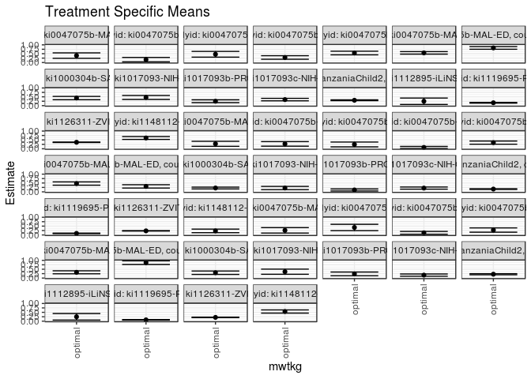

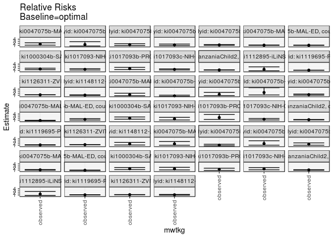

## Results Table

### Parameter: TSM

| agecat | studyid | country | intervention_level | baseline_level | estimate | ci_lower | ci_upper |
| --- | --- | --- | --- | --- | --- | --- | --- |
| 0-24 months | ki0047075b-MAL-ED | BANGLADESH | optimal | NA | 0.3925445 | 0.2389269 | 0.5461622 |
| 0-24 months | ki0047075b-MAL-ED | BRAZIL | optimal | NA | 0.1640982 | 0.0401014 | 0.2880950 |
| 0-24 months | ki0047075b-MAL-ED | INDIA | optimal | NA | 0.4675119 | 0.3048575 | 0.6301662 |
| 0-24 months | ki0047075b-MAL-ED | NEPAL | optimal | NA | 0.2860037 | 0.1859948 | 0.3860127 |
| 0-24 months | ki0047075b-MAL-ED | PERU | optimal | NA | 0.5388965 | 0.4364084 | 0.6413847 |
| 0-24 months | ki0047075b-MAL-ED | SOUTH AFRICA | optimal | NA | 0.5467866 | 0.4764015 | 0.6171717 |
| 0-24 months | ki0047075b-MAL-ED | TANZANIA, UNITED REPUBLIC OF | optimal | NA | 0.8273578 | 0.7515620 | 0.9031535 |
| 0-24 months | ki1000304b-SAS-CompFeed | INDIA | optimal | NA | 0.4282351 | 0.3341369 | 0.5223333 |
| 0-24 months | ki1017093-NIH-Birth | BANGLADESH | optimal | NA | 0.4648513 | 0.3539436 | 0.5757590 |
| 0-24 months | ki1017093b-PROVIDE | BANGLADESH | optimal | NA | 0.2497678 | 0.1692346 | 0.3303010 |
| 0-24 months | ki1017093c-NIH-Crypto | BANGLADESH | optimal | NA | 0.3424927 | 0.2720718 | 0.4129136 |
| 0-24 months | ki1066203-TanzaniaChild2 | TANZANIA, UNITED REPUBLIC OF | optimal | NA | 0.3042810 | 0.2806009 | 0.3279611 |
| 0-24 months | ki1112895-iLiNS-Zinc | BURKINA FASO | optimal | NA | 0.2485545 | 0.0661210 | 0.4309880 |
| 0-24 months | ki1119695-PROBIT | BELARUS | optimal | NA | 0.1629753 | 0.1423094 | 0.1836411 |
| 0-24 months | ki1126311-ZVITAMBO | ZIMBABWE | optimal | NA | 0.3660355 | 0.3532669 | 0.3788041 |
| 0-24 months | ki1148112-LCNI-5 | MALAWI | optimal | NA | 0.6100306 | 0.5285140 | 0.6915471 |
| 0-6 months | ki0047075b-MAL-ED | BANGLADESH | optimal | NA | 0.2794856 | 0.1372691 | 0.4217022 |
| 0-6 months | ki0047075b-MAL-ED | BRAZIL | optimal | NA | 0.2739840 | 0.1456043 | 0.4023636 |
| 0-6 months | ki0047075b-MAL-ED | INDIA | optimal | NA | 0.2433384 | 0.1071565 | 0.3795202 |
| 0-6 months | ki0047075b-MAL-ED | NEPAL | optimal | NA | 0.0746590 | 0.0169267 | 0.1323913 |
| 0-6 months | ki0047075b-MAL-ED | PERU | optimal | NA | 0.3473380 | 0.2573420 | 0.4373341 |
| 0-6 months | ki0047075b-MAL-ED | SOUTH AFRICA | optimal | NA | 0.4697642 | 0.3769217 | 0.5626067 |
| 0-6 months | ki0047075b-MAL-ED | TANZANIA, UNITED REPUBLIC OF | optimal | NA | 0.3090954 | 0.2159711 | 0.4022197 |
| 0-6 months | ki1000304b-SAS-CompFeed | INDIA | optimal | NA | 0.2178809 | 0.1672478 | 0.2685139 |
| 0-6 months | ki1017093-NIH-Birth | BANGLADESH | optimal | NA | 0.2167162 | 0.1268491 | 0.3065832 |
| 0-6 months | ki1017093b-PROVIDE | BANGLADESH | optimal | NA | 0.1082634 | 0.0502743 | 0.1662525 |
| 0-6 months | ki1017093c-NIH-Crypto | BANGLADESH | optimal | NA | 0.2136850 | 0.1527492 | 0.2746208 |
| 0-6 months | ki1066203-TanzaniaChild2 | TANZANIA, UNITED REPUBLIC OF | optimal | NA | 0.1583849 | 0.1394165 | 0.1773533 |
| 0-6 months | ki1119695-PROBIT | BELARUS | optimal | NA | 0.0895470 | 0.0743288 | 0.1047651 |
| 0-6 months | ki1126311-ZVITAMBO | ZIMBABWE | optimal | NA | 0.2321703 | 0.2209289 | 0.2434117 |
| 0-6 months | ki1148112-LCNI-5 | MALAWI | optimal | NA | 0.2300315 | 0.1290565 | 0.3310066 |
| 6-24 months | ki0047075b-MAL-ED | BANGLADESH | optimal | NA | 0.2614218 | 0.1088657 | 0.4139780 |
| 6-24 months | ki0047075b-MAL-ED | INDIA | optimal | NA | 0.4243326 | 0.2453326 | 0.6033327 |
| 6-24 months | ki0047075b-MAL-ED | NEPAL | optimal | NA | 0.1206819 | 0.0412702 | 0.2000936 |
| 6-24 months | ki0047075b-MAL-ED | PERU | optimal | NA | 0.2780142 | 0.1565815 | 0.3994468 |
| 6-24 months | ki0047075b-MAL-ED | SOUTH AFRICA | optimal | NA | 0.3268079 | 0.2419602 | 0.4116556 |
| 6-24 months | ki0047075b-MAL-ED | TANZANIA, UNITED REPUBLIC OF | optimal | NA | 0.8718881 | 0.7693202 | 0.9744560 |
| 6-24 months | ki1000304b-SAS-CompFeed | INDIA | optimal | NA | 0.3033394 | 0.2064085 | 0.4002704 |
| 6-24 months | ki1017093-NIH-Birth | BANGLADESH | optimal | NA | 0.3606063 | 0.2152532 | 0.5059593 |
| 6-24 months | ki1017093b-PROVIDE | BANGLADESH | optimal | NA | 0.2364410 | 0.1311887 | 0.3416933 |
| 6-24 months | ki1017093c-NIH-Crypto | BANGLADESH | optimal | NA | 0.1679871 | 0.1052504 | 0.2307238 |
| 6-24 months | ki1066203-TanzaniaChild2 | TANZANIA, UNITED REPUBLIC OF | optimal | NA | 0.2181003 | 0.1881163 | 0.2480843 |
| 6-24 months | ki1112895-iLiNS-Zinc | BURKINA FASO | optimal | NA | 0.2479047 | 0.0622035 | 0.4336059 |
| 6-24 months | ki1119695-PROBIT | BELARUS | optimal | NA | 0.0754353 | 0.0619794 | 0.0888912 |
| 6-24 months | ki1126311-ZVITAMBO | ZIMBABWE | optimal | NA | 0.2145396 | 0.2009010 | 0.2281783 |
| 6-24 months | ki1148112-LCNI-5 | MALAWI | optimal | NA | 0.5475710 | 0.4574667 | 0.6376753 |

### Parameter: E(Y)

| agecat | studyid | country | intervention_level | baseline_level | estimate | ci_lower | ci_upper |
| --- | --- | --- | --- | --- | --- | --- | --- |
| 0-24 months | ki0047075b-MAL-ED | BANGLADESH | observed | NA | 0.6102362 | 0.5501413 | 0.6703311 |
| 0-24 months | ki0047075b-MAL-ED | BRAZIL | observed | NA | 0.2262443 | 0.1709568 | 0.2815319 |
| 0-24 months | ki0047075b-MAL-ED | INDIA | observed | NA | 0.6074380 | 0.5457864 | 0.6690897 |
| 0-24 months | ki0047075b-MAL-ED | NEPAL | observed | NA | 0.3445378 | 0.2840363 | 0.4050393 |
| 0-24 months | ki0047075b-MAL-ED | PERU | observed | NA | 0.6413793 | 0.5860858 | 0.6966728 |
| 0-24 months | ki0047075b-MAL-ED | SOUTH AFRICA | observed | NA | 0.5888889 | 0.5300901 | 0.6476877 |
| 0-24 months | ki0047075b-MAL-ED | TANZANIA, UNITED REPUBLIC OF | observed | NA | 0.8593750 | 0.8167072 | 0.9020428 |
| 0-24 months | ki1000304b-SAS-CompFeed | INDIA | observed | NA | 0.6908851 | 0.6500577 | 0.7317124 |
| 0-24 months | ki1017093-NIH-Birth | BANGLADESH | observed | NA | 0.6645469 | 0.6276196 | 0.7014742 |
| 0-24 months | ki1017093b-PROVIDE | BANGLADESH | observed | NA | 0.4514200 | 0.4136828 | 0.4891573 |
| 0-24 months | ki1017093c-NIH-Crypto | BANGLADESH | observed | NA | 0.4794702 | 0.4438115 | 0.5151289 |
| 0-24 months | ki1066203-TanzaniaChild2 | TANZANIA, UNITED REPUBLIC OF | observed | NA | 0.3465136 | 0.3272783 | 0.3657490 |
| 0-24 months | ki1112895-iLiNS-Zinc | BURKINA FASO | observed | NA | 0.3559962 | 0.3060347 | 0.4059578 |
| 0-24 months | ki1119695-PROBIT | BELARUS | observed | NA | 0.1694743 | 0.1504830 | 0.1884655 |
| 0-24 months | ki1126311-ZVITAMBO | ZIMBABWE | observed | NA | 0.4356480 | 0.4264663 | 0.4448297 |
| 0-24 months | ki1148112-LCNI-5 | MALAWI | observed | NA | 0.6360382 | 0.6034429 | 0.6686335 |
| 0-6 months | ki0047075b-MAL-ED | BANGLADESH | observed | NA | 0.3464567 | 0.2878227 | 0.4050907 |
| 0-6 months | ki0047075b-MAL-ED | BRAZIL | observed | NA | 0.1855204 | 0.1341547 | 0.2368860 |
| 0-6 months | ki0047075b-MAL-ED | INDIA | observed | NA | 0.3429752 | 0.2830428 | 0.4029076 |
| 0-6 months | ki0047075b-MAL-ED | NEPAL | observed | NA | 0.1722689 | 0.1241936 | 0.2203442 |
| 0-6 months | ki0047075b-MAL-ED | PERU | observed | NA | 0.4413793 | 0.3841309 | 0.4986278 |
| 0-6 months | ki0047075b-MAL-ED | SOUTH AFRICA | observed | NA | 0.3814815 | 0.3234338 | 0.4395292 |
| 0-6 months | ki0047075b-MAL-ED | TANZANIA, UNITED REPUBLIC OF | observed | NA | 0.4179688 | 0.3574314 | 0.4785061 |
| 0-6 months | ki1000304b-SAS-CompFeed | INDIA | observed | NA | 0.4228987 | 0.3938571 | 0.4519404 |
| 0-6 months | ki1017093-NIH-Birth | BANGLADESH | observed | NA | 0.3497615 | 0.3124631 | 0.3870600 |
| 0-6 months | ki1017093b-PROVIDE | BANGLADESH | observed | NA | 0.2466368 | 0.2139486 | 0.2793250 |
| 0-6 months | ki1017093c-NIH-Crypto | BANGLADESH | observed | NA | 0.3033113 | 0.2704998 | 0.3361228 |
| 0-6 months | ki1066203-TanzaniaChild2 | TANZANIA, UNITED REPUBLIC OF | observed | NA | 0.1943027 | 0.1783091 | 0.2102964 |
| 0-6 months | ki1119695-PROBIT | BELARUS | observed | NA | 0.0970084 | 0.0840167 | 0.1100001 |
| 0-6 months | ki1126311-ZVITAMBO | ZIMBABWE | observed | NA | 0.2815517 | 0.2732174 | 0.2898859 |
| 0-6 months | ki1148112-LCNI-5 | MALAWI | observed | NA | 0.3579336 | 0.3007518 | 0.4151153 |
| 6-24 months | ki0047075b-MAL-ED | BANGLADESH | observed | NA | 0.4213836 | 0.3443902 | 0.4983771 |
| 6-24 months | ki0047075b-MAL-ED | INDIA | observed | NA | 0.4129032 | 0.3351414 | 0.4906651 |
| 6-24 months | ki0047075b-MAL-ED | NEPAL | observed | NA | 0.2102564 | 0.1529155 | 0.2675974 |
| 6-24 months | ki0047075b-MAL-ED | PERU | observed | NA | 0.3918919 | 0.3129763 | 0.4708075 |
| 6-24 months | ki0047075b-MAL-ED | SOUTH AFRICA | observed | NA | 0.3589744 | 0.2834562 | 0.4344926 |
| 6-24 months | ki0047075b-MAL-ED | TANZANIA, UNITED REPUBLIC OF | observed | NA | 0.7793103 | 0.7115754 | 0.8470453 |
| 6-24 months | ki1000304b-SAS-CompFeed | INDIA | observed | NA | 0.5024691 | 0.4579693 | 0.5469690 |
| 6-24 months | ki1017093-NIH-Birth | BANGLADESH | observed | NA | 0.5739130 | 0.5216565 | 0.6261696 |
| 6-24 months | ki1017093b-PROVIDE | BANGLADESH | observed | NA | 0.2997812 | 0.2577294 | 0.3418330 |
| 6-24 months | ki1017093c-NIH-Crypto | BANGLADESH | observed | NA | 0.2628458 | 0.2244546 | 0.3012371 |
| 6-24 months | ki1066203-TanzaniaChild2 | TANZANIA, UNITED REPUBLIC OF | observed | NA | 0.2277354 | 0.2069978 | 0.2484730 |
| 6-24 months | ki1112895-iLiNS-Zinc | BURKINA FASO | observed | NA | 0.3559962 | 0.3060347 | 0.4059578 |
| 6-24 months | ki1119695-PROBIT | BELARUS | observed | NA | 0.0803025 | 0.0658938 | 0.0947113 |
| 6-24 months | ki1126311-ZVITAMBO | ZIMBABWE | observed | NA | 0.2460554 | 0.2359900 | 0.2561209 |
| 6-24 months | ki1148112-LCNI-5 | MALAWI | observed | NA | 0.5989011 | 0.5632737 | 0.6345285 |

### Parameter: RR

| agecat | studyid | country | intervention_level | baseline_level | estimate | ci_lower | ci_upper |
| --- | --- | --- | --- | --- | --- | --- | --- |
| 0-24 months | ki0047075b-MAL-ED | BANGLADESH | observed | optimal | 1.5545655 | 1.0834746 | 2.2304851 |
| 0-24 months | ki0047075b-MAL-ED | BRAZIL | observed | optimal | 1.3787134 | 0.6805252 | 2.7932109 |
| 0-24 months | ki0047075b-MAL-ED | INDIA | observed | optimal | 1.2992996 | 0.9445469 | 1.7872902 |
| 0-24 months | ki0047075b-MAL-ED | NEPAL | observed | optimal | 1.2046619 | 0.8987661 | 1.6146696 |
| 0-24 months | ki0047075b-MAL-ED | PERU | observed | optimal | 1.1901715 | 1.0157091 | 1.3946004 |
| 0-24 months | ki0047075b-MAL-ED | SOUTH AFRICA | observed | optimal | 1.0769995 | 1.0072260 | 1.1516065 |
| 0-24 months | ki0047075b-MAL-ED | TANZANIA, UNITED REPUBLIC OF | observed | optimal | 1.0386981 | 0.9695691 | 1.1127560 |
| 0-24 months | ki1000304b-SAS-CompFeed | INDIA | observed | optimal | 1.6133314 | 1.2911887 | 2.0158464 |
| 0-24 months | ki1017093-NIH-Birth | BANGLADESH | observed | optimal | 1.4295903 | 1.1432256 | 1.7876861 |
| 0-24 months | ki1017093b-PROVIDE | BANGLADESH | observed | optimal | 1.8073588 | 1.3359659 | 2.4450819 |
| 0-24 months | ki1017093c-NIH-Crypto | BANGLADESH | observed | optimal | 1.3999428 | 1.1650040 | 1.6822601 |
| 0-24 months | ki1066203-TanzaniaChild2 | TANZANIA, UNITED REPUBLIC OF | observed | optimal | 1.1387948 | 1.0824702 | 1.1980501 |
| 0-24 months | ki1112895-iLiNS-Zinc | BURKINA FASO | observed | optimal | 1.4322662 | 0.7677111 | 2.6720811 |
| 0-24 months | ki1119695-PROBIT | BELARUS | observed | optimal | 1.0398775 | 1.0021404 | 1.0790356 |
| 0-24 months | ki1126311-ZVITAMBO | ZIMBABWE | observed | optimal | 1.1901796 | 1.1600123 | 1.2211313 |
| 0-24 months | ki1148112-LCNI-5 | MALAWI | observed | optimal | 1.0426333 | 0.9237954 | 1.1767586 |
| 0-6 months | ki0047075b-MAL-ED | BANGLADESH | observed | optimal | 1.2396225 | 0.7753252 | 1.9819607 |
| 0-6 months | ki0047075b-MAL-ED | BRAZIL | observed | optimal | 0.6771212 | 0.4417315 | 1.0379453 |
| 0-6 months | ki0047075b-MAL-ED | INDIA | observed | optimal | 1.4094580 | 0.8377458 | 2.3713301 |
| 0-6 months | ki0047075b-MAL-ED | NEPAL | observed | optimal | 2.3074105 | 1.1368405 | 4.6832805 |
| 0-6 months | ki0047075b-MAL-ED | PERU | observed | optimal | 1.2707487 | 1.0254384 | 1.5747432 |
| 0-6 months | ki0047075b-MAL-ED | SOUTH AFRICA | observed | optimal | 0.8120702 | 0.6948986 | 0.9489988 |
| 0-6 months | ki0047075b-MAL-ED | TANZANIA, UNITED REPUBLIC OF | observed | optimal | 1.3522320 | 1.0538536 | 1.7350905 |
| 0-6 months | ki1000304b-SAS-CompFeed | INDIA | observed | optimal | 1.9409631 | 1.4722408 | 2.5589142 |
| 0-6 months | ki1017093-NIH-Birth | BANGLADESH | observed | optimal | 1.6139151 | 1.0887212 | 2.3924602 |
| 0-6 months | ki1017093b-PROVIDE | BANGLADESH | observed | optimal | 2.2781178 | 1.3639988 | 3.8048571 |
| 0-6 months | ki1017093c-NIH-Crypto | BANGLADESH | observed | optimal | 1.4194318 | 1.0959010 | 1.8384750 |
| 0-6 months | ki1066203-TanzaniaChild2 | TANZANIA, UNITED REPUBLIC OF | observed | optimal | 1.2267757 | 1.1288621 | 1.3331821 |
| 0-6 months | ki1119695-PROBIT | BELARUS | observed | optimal | 1.0833247 | 0.9980096 | 1.1759329 |
| 0-6 months | ki1126311-ZVITAMBO | ZIMBABWE | observed | optimal | 1.2126947 | 1.1688694 | 1.2581631 |
| 0-6 months | ki1148112-LCNI-5 | MALAWI | observed | optimal | 1.5560195 | 1.0484037 | 2.3094127 |
| 6-24 months | ki0047075b-MAL-ED | BANGLADESH | observed | optimal | 1.6118915 | 0.9450670 | 2.7492169 |
| 6-24 months | ki0047075b-MAL-ED | INDIA | observed | optimal | 0.9730650 | 0.6670359 | 1.4194970 |
| 6-24 months | ki0047075b-MAL-ED | NEPAL | observed | optimal | 1.7422363 | 0.9722000 | 3.1221840 |
| 6-24 months | ki0047075b-MAL-ED | PERU | observed | optimal | 1.4096113 | 0.9614006 | 2.0667805 |
| 6-24 months | ki0047075b-MAL-ED | SOUTH AFRICA | observed | optimal | 1.0984262 | 0.9587921 | 1.2583960 |
| 6-24 months | ki0047075b-MAL-ED | TANZANIA, UNITED REPUBLIC OF | observed | optimal | 0.8938192 | 0.8009942 | 0.9974015 |
| 6-24 months | ki1000304b-SAS-CompFeed | INDIA | observed | optimal | 1.6564585 | 1.2288176 | 2.2329226 |
| 6-24 months | ki1017093-NIH-Birth | BANGLADESH | observed | optimal | 1.5915227 | 1.0885835 | 2.3268262 |
| 6-24 months | ki1017093b-PROVIDE | BANGLADESH | observed | optimal | 1.2678901 | 0.8443456 | 1.9038948 |
| 6-24 months | ki1017093c-NIH-Crypto | BANGLADESH | observed | optimal | 1.5646792 | 1.1218247 | 2.1823561 |
| 6-24 months | ki1066203-TanzaniaChild2 | TANZANIA, UNITED REPUBLIC OF | observed | optimal | 1.0441773 | 0.9435037 | 1.1555931 |
| 6-24 months | ki1112895-iLiNS-Zinc | BURKINA FASO | observed | optimal | 1.4360205 | 0.7585653 | 2.7184935 |
| 6-24 months | ki1119695-PROBIT | BELARUS | observed | optimal | 1.0645220 | 0.9911258 | 1.1433534 |
| 6-24 months | ki1126311-ZVITAMBO | ZIMBABWE | observed | optimal | 1.1468997 | 1.0936725 | 1.2027173 |
| 6-24 months | ki1148112-LCNI-5 | MALAWI | observed | optimal | 1.0937414 | 0.9391083 | 1.2738363 |

### Parameter: PAR

| agecat | studyid | country | intervention_level | baseline_level | estimate | ci_lower | ci_upper |
| --- | --- | --- | --- | --- | --- | --- | --- |
| 0-24 months | ki0047075b-MAL-ED | BANGLADESH | optimal | NA | 0.2176917 | 0.0783247 | 0.3570587 |
| 0-24 months | ki0047075b-MAL-ED | BRAZIL | optimal | NA | 0.0621462 | -0.0541469 | 0.1784392 |
| 0-24 months | ki0047075b-MAL-ED | INDIA | optimal | NA | 0.1399261 | -0.0078342 | 0.2876864 |
| 0-24 months | ki0047075b-MAL-ED | NEPAL | optimal | NA | 0.0585341 | -0.0253135 | 0.1423816 |
| 0-24 months | ki0047075b-MAL-ED | PERU | optimal | NA | 0.1024828 | 0.0177755 | 0.1871900 |
| 0-24 months | ki0047075b-MAL-ED | SOUTH AFRICA | optimal | NA | 0.0421023 | 0.0059049 | 0.0782997 |
| 0-24 months | ki0047075b-MAL-ED | TANZANIA, UNITED REPUBLIC OF | optimal | NA | 0.0320172 | -0.0247107 | 0.0887451 |
| 0-24 months | ki1000304b-SAS-CompFeed | INDIA | optimal | NA | 0.2626500 | 0.1632454 | 0.3620546 |
| 0-24 months | ki1017093-NIH-Birth | BANGLADESH | optimal | NA | 0.1996956 | 0.0969273 | 0.3024639 |
| 0-24 months | ki1017093b-PROVIDE | BANGLADESH | optimal | NA | 0.2016522 | 0.1261693 | 0.2771351 |
| 0-24 months | ki1017093c-NIH-Crypto | BANGLADESH | optimal | NA | 0.1369775 | 0.0743527 | 0.1996023 |
| 0-24 months | ki1066203-TanzaniaChild2 | TANZANIA, UNITED REPUBLIC OF | optimal | NA | 0.0422326 | 0.0267873 | 0.0576779 |
| 0-24 months | ki1112895-iLiNS-Zinc | BURKINA FASO | optimal | NA | 0.1074417 | -0.0366978 | 0.2515813 |
| 0-24 months | ki1119695-PROBIT | BELARUS | optimal | NA | 0.0064990 | 0.0006220 | 0.0123761 |
| 0-24 months | ki1126311-ZVITAMBO | ZIMBABWE | optimal | NA | 0.0696125 | 0.0602545 | 0.0789704 |
| 0-24 months | ki1148112-LCNI-5 | MALAWI | optimal | NA | 0.0260076 | -0.0477638 | 0.0997791 |
| 0-6 months | ki0047075b-MAL-ED | BANGLADESH | optimal | NA | 0.0669711 | -0.0639573 | 0.1978994 |
| 0-6 months | ki0047075b-MAL-ED | BRAZIL | optimal | NA | -0.0884636 | -0.2039517 | 0.0270245 |
| 0-6 months | ki0047075b-MAL-ED | INDIA | optimal | NA | 0.0996368 | -0.0270065 | 0.2262802 |
| 0-6 months | ki0047075b-MAL-ED | NEPAL | optimal | NA | 0.0976099 | 0.0393295 | 0.1558904 |
| 0-6 months | ki0047075b-MAL-ED | PERU | optimal | NA | 0.0940413 | 0.0194878 | 0.1685948 |
| 0-6 months | ki0047075b-MAL-ED | SOUTH AFRICA | optimal | NA | -0.0882827 | -0.1603332 | -0.0162322 |
| 0-6 months | ki0047075b-MAL-ED | TANZANIA, UNITED REPUBLIC OF | optimal | NA | 0.1088733 | 0.0318697 | 0.1858769 |
| 0-6 months | ki1000304b-SAS-CompFeed | INDIA | optimal | NA | 0.2050179 | 0.1340545 | 0.2759812 |
| 0-6 months | ki1017093-NIH-Birth | BANGLADESH | optimal | NA | 0.1330453 | 0.0475027 | 0.2185880 |
| 0-6 months | ki1017093b-PROVIDE | BANGLADESH | optimal | NA | 0.1383734 | 0.0806964 | 0.1960503 |
| 0-6 months | ki1017093c-NIH-Crypto | BANGLADESH | optimal | NA | 0.0896263 | 0.0339694 | 0.1452831 |
| 0-6 months | ki1066203-TanzaniaChild2 | TANZANIA, UNITED REPUBLIC OF | optimal | NA | 0.0359178 | 0.0225532 | 0.0492825 |
| 0-6 months | ki1119695-PROBIT | BELARUS | optimal | NA | 0.0074615 | 0.0002411 | 0.0146818 |
| 0-6 months | ki1126311-ZVITAMBO | ZIMBABWE | optimal | NA | 0.0493814 | 0.0407868 | 0.0579759 |
| 0-6 months | ki1148112-LCNI-5 | MALAWI | optimal | NA | 0.1279020 | 0.0365961 | 0.2192079 |
| 6-24 months | ki0047075b-MAL-ED | BANGLADESH | optimal | NA | 0.1599618 | 0.0206378 | 0.2992858 |
| 6-24 months | ki0047075b-MAL-ED | INDIA | optimal | NA | -0.0114294 | -0.1716732 | 0.1488144 |
| 6-24 months | ki0047075b-MAL-ED | NEPAL | optimal | NA | 0.0895745 | 0.0163953 | 0.1627537 |
| 6-24 months | ki0047075b-MAL-ED | PERU | optimal | NA | 0.1138777 | 0.0055970 | 0.2221585 |
| 6-24 months | ki0047075b-MAL-ED | SOUTH AFRICA | optimal | NA | 0.0321665 | -0.0122297 | 0.0765626 |
| 6-24 months | ki0047075b-MAL-ED | TANZANIA, UNITED REPUBLIC OF | optimal | NA | -0.0925777 | -0.1860729 | 0.0009175 |
| 6-24 months | ki1000304b-SAS-CompFeed | INDIA | optimal | NA | 0.1991297 | 0.1085230 | 0.2897364 |
| 6-24 months | ki1017093-NIH-Birth | BANGLADESH | optimal | NA | 0.2133068 | 0.0777604 | 0.3488532 |
| 6-24 months | ki1017093b-PROVIDE | BANGLADESH | optimal | NA | 0.0633402 | -0.0321645 | 0.1588448 |
| 6-24 months | ki1017093c-NIH-Crypto | BANGLADESH | optimal | NA | 0.0948588 | 0.0383118 | 0.1514058 |
| 6-24 months | ki1066203-TanzaniaChild2 | TANZANIA, UNITED REPUBLIC OF | optimal | NA | 0.0096351 | -0.0124786 | 0.0317488 |
| 6-24 months | ki1112895-iLiNS-Zinc | BURKINA FASO | optimal | NA | 0.1080915 | -0.0391072 | 0.2552902 |
| 6-24 months | ki1119695-PROBIT | BELARUS | optimal | NA | 0.0048672 | -0.0007734 | 0.0105079 |
| 6-24 months | ki1126311-ZVITAMBO | ZIMBABWE | optimal | NA | 0.0315158 | 0.0212756 | 0.0417560 |
| 6-24 months | ki1148112-LCNI-5 | MALAWI | optimal | NA | 0.0513301 | -0.0321401 | 0.1348003 |

### Parameter: PAF

| agecat | studyid | country | intervention_level | baseline_level | estimate | ci_lower | ci_upper |
| --- | --- | --- | --- | --- | --- | --- | --- |
| 0-24 months | ki0047075b-MAL-ED | BANGLADESH | optimal | NA | 0.3567335 | 0.0770435 | 0.5516670 |
| 0-24 months | ki0047075b-MAL-ED | BRAZIL | optimal | NA | 0.2746861 | -0.4694532 | 0.6419891 |
| 0-24 months | ki0047075b-MAL-ED | INDIA | optimal | NA | 0.2303546 | -0.0587086 | 0.4404938 |
| 0-24 months | ki0047075b-MAL-ED | NEPAL | optimal | NA | 0.1698916 | -0.1126365 | 0.3806782 |
| 0-24 months | ki0047075b-MAL-ED | PERU | optimal | NA | 0.1597850 | 0.0154661 | 0.2829487 |
| 0-24 months | ki0047075b-MAL-ED | SOUTH AFRICA | optimal | NA | 0.0714945 | 0.0071742 | 0.1316478 |
| 0-24 months | ki0047075b-MAL-ED | TANZANIA, UNITED REPUBLIC OF | optimal | NA | 0.0372564 | -0.0313860 | 0.1013304 |
| 0-24 months | ki1000304b-SAS-CompFeed | INDIA | optimal | NA | 0.3801645 | 0.2255199 | 0.5039305 |
| 0-24 months | ki1017093-NIH-Birth | BANGLADESH | optimal | NA | 0.3004989 | 0.1252820 | 0.4406177 |
| 0-24 months | ki1017093b-PROVIDE | BANGLADESH | optimal | NA | 0.4467064 | 0.2514779 | 0.5910157 |
| 0-24 months | ki1017093c-NIH-Crypto | BANGLADESH | optimal | NA | 0.2856851 | 0.1416338 | 0.4055616 |
| 0-24 months | ki1066203-TanzaniaChild2 | TANZANIA, UNITED REPUBLIC OF | optimal | NA | 0.1218786 | 0.0761870 | 0.1653103 |
| 0-24 months | ki1112895-iLiNS-Zinc | BURKINA FASO | optimal | NA | 0.3018058 | -0.3025733 | 0.6257599 |
| 0-24 months | ki1119695-PROBIT | BELARUS | optimal | NA | 0.0383482 | 0.0021358 | 0.0732465 |
| 0-24 months | ki1126311-ZVITAMBO | ZIMBABWE | optimal | NA | 0.1597906 | 0.1379402 | 0.1810873 |
| 0-24 months | ki1148112-LCNI-5 | MALAWI | optimal | NA | 0.0408900 | -0.0824908 | 0.1502080 |
| 0-6 months | ki0047075b-MAL-ED | BANGLADESH | optimal | NA | 0.1933028 | -0.2897814 | 0.4954491 |
| 0-6 months | ki0047075b-MAL-ED | BRAZIL | optimal | NA | -0.4768404 | -1.2638185 | 0.0365581 |
| 0-6 months | ki0047075b-MAL-ED | INDIA | optimal | NA | 0.2905074 | -0.1936795 | 0.5782957 |
| 0-6 months | ki0047075b-MAL-ED | NEPAL | optimal | NA | 0.5666137 | 0.1203692 | 0.7864745 |
| 0-6 months | ki0047075b-MAL-ED | PERU | optimal | NA | 0.2130623 | 0.0248073 | 0.3649758 |
| 0-6 months | ki0047075b-MAL-ED | SOUTH AFRICA | optimal | NA | -0.2314207 | -0.4390589 | -0.0537421 |
| 0-6 months | ki0047075b-MAL-ED | TANZANIA, UNITED REPUBLIC OF | optimal | NA | 0.2604819 | 0.0511016 | 0.4236612 |
| 0-6 months | ki1000304b-SAS-CompFeed | INDIA | optimal | NA | 0.4847919 | 0.3207633 | 0.6092093 |
| 0-6 months | ki1017093-NIH-Birth | BANGLADESH | optimal | NA | 0.3803887 | 0.0814912 | 0.5820202 |
| 0-6 months | ki1017093b-PROVIDE | BANGLADESH | optimal | NA | 0.5610411 | 0.2668615 | 0.7371780 |
| 0-6 months | ki1017093c-NIH-Crypto | BANGLADESH | optimal | NA | 0.2954928 | 0.0875089 | 0.4560709 |
| 0-6 months | ki1066203-TanzaniaChild2 | TANZANIA, UNITED REPUBLIC OF | optimal | NA | 0.1848551 | 0.1141522 | 0.2499149 |
| 0-6 months | ki1119695-PROBIT | BELARUS | optimal | NA | 0.0769157 | -0.0019944 | 0.1496114 |
| 0-6 months | ki1126311-ZVITAMBO | ZIMBABWE | optimal | NA | 0.1753901 | 0.1444724 | 0.2051905 |
| 0-6 months | ki1148112-LCNI-5 | MALAWI | optimal | NA | 0.3573345 | 0.0461690 | 0.5669895 |
| 6-24 months | ki0047075b-MAL-ED | BANGLADESH | optimal | NA | 0.3796108 | -0.0581261 | 0.6362601 |
| 6-24 months | ki0047075b-MAL-ED | INDIA | optimal | NA | -0.0276806 | -0.4991697 | 0.2955251 |
| 6-24 months | ki0047075b-MAL-ED | NEPAL | optimal | NA | 0.4260251 | -0.0285949 | 0.6797114 |
| 6-24 months | ki0047075b-MAL-ED | PERU | optimal | NA | 0.2905846 | -0.0401492 | 0.5161557 |
| 6-24 months | ki0047075b-MAL-ED | SOUTH AFRICA | optimal | NA | 0.0896066 | -0.0429790 | 0.2053376 |
| 6-24 months | ki0047075b-MAL-ED | TANZANIA, UNITED REPUBLIC OF | optimal | NA | -0.1187944 | -0.2484485 | -0.0026053 |
| 6-24 months | ki1000304b-SAS-CompFeed | INDIA | optimal | NA | 0.3963024 | 0.1862096 | 0.5521565 |
| 6-24 months | ki1017093-NIH-Birth | BANGLADESH | optimal | NA | 0.3716709 | 0.0813750 | 0.5702300 |
| 6-24 months | ki1017093b-PROVIDE | BANGLADESH | optimal | NA | 0.2112881 | -0.1843492 | 0.4747609 |
| 6-24 months | ki1017093c-NIH-Crypto | BANGLADESH | optimal | NA | 0.3608914 | 0.1085952 | 0.5417796 |
| 6-24 months | ki1066203-TanzaniaChild2 | TANZANIA, UNITED REPUBLIC OF | optimal | NA | 0.0423083 | -0.0598793 | 0.1346435 |
| 6-24 months | ki1112895-iLiNS-Zinc | BURKINA FASO | optimal | NA | 0.3036311 | -0.3182781 | 0.6321492 |
| 6-24 months | ki1119695-PROBIT | BELARUS | optimal | NA | 0.0606112 | -0.0089536 | 0.1253798 |
| 6-24 months | ki1126311-ZVITAMBO | ZIMBABWE | optimal | NA | 0.1280842 | 0.0856495 | 0.1685494 |
| 6-24 months | ki1148112-LCNI-5 | MALAWI | optimal | NA | 0.0857071 | -0.0648399 | 0.2149698 |